# FMBN5tablespecsv1_0

[figure not shown]

**FoodMicrobionet 5: Structure of edges and nodes tables**.

Prof. Eugenio Parente. Scuola di Scienze Agrarie, Forestali, Alimentari ed Ambientali, Università degli Studi della Basilicata.

This document describes the structure of data tables for FoodMicrobionet (FMBN) version 5 (v5)

The structure of the database was changed and is now more coherent with that of a relational database, to facilitate extraction of data. It now includes:

The structure of the database is illustrated in Figure 1.

The emphasis is now on data extraction and processing using a range of R Shiny apps, and most of the new features were designed to facilitate processing with other software packages (Microsoft Excel, Gephi, Cytoscape, the CoNet App of Cytoscape, the bipartite package and the phyloseq package of R). To learn more on FMBN: http://web.unibas.it/parente/?page_id=761 .

All scripts are available at https://github.com/ep142/FoodMicrobionet.

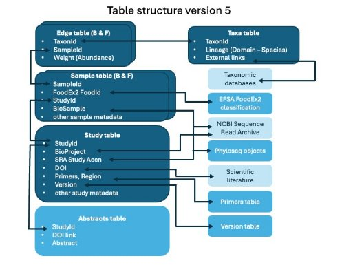

**Figure 1**. Structure and relationships in FoodMicrobionet. FoodMicrobionet main tables are in dark blue. FMBN secondary tables are in turquoise. External resources are in pale blue

**The studies table**.

This table lists all relevant information for the study. The table has the following fields (each study is a record)

1. **study**: a numerical (integer) id for the study
2. **studyId**: an ID for the study (in the format STx, where x is an integer with the study number); this is assigned as studies are added to FMBN (see samples table)
3. **FMBN_version**: the version of FMBN in which the study appeared for the first time (unless stated otherwise, the study will appear in all further versions)
4. **target**: the gene target(s) used for amplification
5. **region**: the region of the 16S RNA or ITS target used for amplification
6. **platform**: the sequencing platform
7. **read_length_bp**: the average read length
8. **seq_center**: the sequencing centre
9. **bioinf_software**: the bioinformatics software/pipeline used for the analysis
10. **OTU_picking**: the OTU picking method
11. **assign_tax_method**: the taxonomy assignment method
12. **tax_database**: the taxonomic database(s) used for annotation
13. **seq_accn**: the accession number for the SRA study, if available, empty otherwise (will become NA in R)
14. **seq_accn_link**: the hyperlink to the run selector for the SRA study, if available, otherwise will point to a page in the FMBN website
15. **bioproject**: SRA bioproject id if available
16. **samples**: the number of samples included in FMBN
17. **food_group**: the food group (for tabulation purposes)
18. **short_descr**: a short description of the study including FoodId (see samples table)
19. **DOI**: the DOI of the study, if published, “unpublished” otherwise
20. **DOI_link**: the DOI hyperlink
21. **ref_short**: an abbreviated reference to the published paper, if available
22. **year**: publication year; if missing, the year the experiment was carried out
23. **ref_complete**: a complete reference to the paper describing the study, “unpublished” otherwise
24. **corr_author**: corresponding author surname
25. **corr_author_mail**: corresponding author e-mail address
26. **geoloc**: a list of the countries in which the samples were obtained; see samples table
27. **study_type**: the study type; cross-sectional, if there are not multiple time points for each treatment/sample type, longitudinal, if there are at least 5 time points for each treatment/sample type, mixed otherwise; this is followed by two numbers in the format *mxn* where *m* is the number of treatments/sample types and *n* the number of time points[^2]; the number of replicates, if any, can be estimated from these figures and the total number of samples in the study
28. **primer_f**: forward primer used for amplification (see primers table)
29. **primer_r**: reverse primer used for amplification (see primers table)
30. **overlapping**: logical flag indicating if during processing paired end sequences overlapped correctly (if not a 10N spacer was added between forward and reverse, see documentation for DADA2)
31. **paired_end**: logical flag indicating if paired end sequences were available[^3]

**The primers table**.

The **primers** table includes some information on the primers (when available). This can be useful if a user wants to repeat the processing of raw sequences. The following fields are included

1. **primer**: the name of the primer (must be unique)
2. **sequence**: the sequence of the primer without adapters and spacers
3. **region**: the 16S region
4. **start**: start nucleotide
5. **length**: length in bp (calculated from sequence)
6. **note:** notes

**The samples table**.

Future iterations of this table may contain further metadata on environmental variables (pH, a<sub>W</sub>, etc.) as measured or estimated values.

**The taxa table**.

The **taxa** table includes information on the lineages of taxa included in FMBN and outlinks to external resources (NCBI taxonomy, [List of Prokaryotic Names with Standing in Nomenclature](https://lpsn.dsmz.de/)<sub>,</sub> [Omnicrobe](https://omnicrobe.migale.inrae.fr/)). It is linked to the edges table by the taxonId field.

1. **taxonId**: an integer with the number of the taxon (taxa are given a progressive number when added to FMBN as a result of the addition of a sample-taxon relationship)
2. **label**: a label for the taxon; must be unique; corresponds to the binomial for the species (if available) or to a higher taxon (genus, family, etc. + _unidentified) when the OTU was not identified at the species level
3. **lineage fields**: the order is not used in this version; when the information is not available the field is left empty
   1. **domain**
   2. **phylum**
   3. **class**
   4. **order**
   5. **family**
   6. **genus**
   7. **species**
4. **id_L6** the taxonomic assignment including the lineage in the format[^11]: Root:k__Bacteria__Firmicutes:c__Bacilli:f__Lactobacillaceae:g__Lactobacillus:s__Lactobacillusdelbrueckii
5. **taxonomy**: a lineage built for compatibility with the CoNet app of Cytoscape (this will most likely removed in future versions, as there are much better ways of estimating microbial association networks)
6. **idelevel**: the taxonomic level of identification (domain, …, species)
7. **NCBI_outlink**: outlink to NCBI taxonomy
8. **Secondary_outlink**: outlink to LPSN for bacteria
9. **Omni_habitat**: outlink to the Florilege database (taxon lives in habitat tab)
10. **Omni_pheno**: outlink to the Florilege database (taxon exhibits phenotype tab)
11. **Omni_use**: outlink to the Florilege database (taxon studied for use tab)

**The edges table**.

The **edges table** includes a list of all relationships between taxa and samples (food or food environment). The fields included in the current version of FoodMicrobionet are:

1. **sampleId** (Food/food environment sample): an integer with the number of the sample (samples are given a progressive number when added to FMBN), link to the same field in the samples table
2. **taxonId**: an integer with the number of the taxon, link to the same field of the taxa table
3. **weight**: the OTU abundance in the sample: for (FMBN) historical reasons this is in %[^12] but is converted in frequency (0-1) or absolute abundance during filtering and selection in the ShinyFMBN app.

**The Abstracts table**.

This table is included for reference purposes, since a few fields are already included in the Samples table. In the future I plan to implement a free text search in ShinyFMBN. The table is only included in FMBNplus

1. **StudyId**: the study id, link to the Study and Sample table
2. **DOI_link**: for convenience only, taken from the Study table
3. **Abstract**: a long text field with the abstract for the publication describing the study.

**The FoodEx2 exposure table**.

This table is included for reference purposes, since a few fields are already included in the Samples table. However, users may conceivably want to use level of aggregation (L2, L3, L5) which are not included in FoodMicrobionet or pool FoodId codes under a code of higher hierarchical level.

1. **Code**: the unique identifier for a food or food category, matches FoodId in the samples table (unique)
2. **L1**: the level 1 in the classification, matches L1 in the samples table
3. **L2**: the level 1 in the classification
4. **L3**: the level 1 in the classification
5. **L4**: the level 1 in the classification, matches L4 in the Samples table
6. **L5**: the level 1 in the classification
7. **L6**: the level 1 in the classification, unique, matches L6 in the Samples table

**The version history table**.

A very simple table with information on publication history for each version of FMBN

1. version: the version number
2. release notes: information on features of the version
3. citation: information on the first publication for each version, if available.

**References**.

- EFSA (2015). The food classification and description system FoodEx 2 (revision 2). Supporting publications EFSA Supporting publication 2015:EN-804. http://www.efsa.europa.eu/en/supporting/pub/215e.htm
- Parente, E., Cocolin, L., De Filippis, F., Zotta, T., Ferrocino, I., O’Sullivan, O., Neviani, E., De Angelis, M., Cotter, P. D., Ercolini D. (2016). FoodMicrobionet: A database for the visualisation and exploration of food bacterial communities based on network analysis. *International Journal of Food Microbiology*, *219*, 28–37. http://doi.org/10.1016/j.ijfoodmicro.2015.12.001
- Parente, E., De Filippis, F., Ercolini, D., Ricciardi, A., Zotta, T., 2019. Advancing integration of data on food microbiome studies: FoodMicrobionet 3.1, a major upgrade of the FoodMicrobionet database. *International Journal of Food Microbiology*, 305, 108249. https://doi.org/10.1016/j.ijfoodmicro.2019.108249
- Parente, E., Zotta, T., Ricciardi, A., 2022. FoodMicrobionet v4: A large, integrated, open and transparent database for food bacterial communities. Int J Food Microbiol 372, 109696. https://doi.org/10.1016/j.ijfoodmicro.2022.109696
- Parente, E., Zotta, T., Ricciardi, A., 2022. FoodMicrobionet v4: A large, integrated, open and transparent database for food bacterial communities. Int J Food Microbiol 372, 109696. https://doi.org/10.1016/j.ijfoodmicro.2022.109696 3

FMBN5Tablespecs v1.0, 19/04/2024, EP

[^1]: A study has a unique accession number; in some cases, sequences for samples belonging to the same study had been deposited with different bioprojects. In this case two entries were created in the study table but the occurrence of a second study was noted and every effort was made to manually match the samples
[^2]: If n is in the format x-y it indicates the range of time points
[^3]: This is not necessarily true for all sequences obtained by Illumina, because in some cases only forward sequences were deposited in SRA
[^4]: Due to errors in the uploading of sequences and their metadata it might indeed happen that the same samples have different biosample accession; correcting this issue is error prone; therefore we have decided to use the same description for samples which have both sequences for bacteria and for fungi only when all or part of the biosample accessions match
[^5]: this is one of the fields used for filtering and labelling (in graphs)
[^6]: there is an issue with food samples obtained during processing of, for example, a hard, ripened cheese. A cheese curd is quite obviously a completely different environment compared to a mature hard cheese. This issue is dealt with by the “Nature” field; when the correct classification is not found in FoodEx or information are partially missing the closest relative is used.
[^7]: I am also considering the addition of a field with FoodOn classification, form compatibility purposes
[^8]: in the future we may add info on intrinsic factors (pH, a<sub>W</sub>) or extrinsic factors (temperature used during storage/ripening, atmosphere); however, this information is (alas!) often missing and may need to be inferred by knowledge on the process; as an alternative one may add facets from FoodEx2, see table 22 and 25 of the document. However, this may be difficult because sample description in published studies is often incomplete.
[^9]: this is applicable to ready to eat foods. Both type1 and type2 may include fermented foods which have been submitted to a heat treatment ACMSF, 2007. Report on safe cooking of burgers. Retrieved from http://www.food.gov. uk/multimedia/pdfs/acmsfburgers0807.pdf.
[^10]: includes foods at the end of shelf life, even if they do not show clear spoilage.
[^11]: It is important to understand that the original taxonomic lineage obtained when directly analysing sequences from SRA/ENA or from contributors is manually edited for coherence. Contributors have submitted in the past OTU abundance tables with lineages in different formats and obtained from different version of taxonomic reference databases; as a result, the same taxon often had a different lineage, especially for *incertae sedis* taxa. When a new lineage is added several steps are carried out: lineages pointing to the same (at the genus, family, class, phylum level) taxon are merged; the lineage is checked against SILVA classification, bad taxa (taxa missing one level of classification) are fixed and a few genera are edited to allow linking to external database (*Corynebacterium_1* becomes *Corynebacterium*). When any of the taxonomic terms (k__; p__, c__, etc.) the corresponding column is left blank.
[^12]: this was needed to set correctly node size in Gephi; proportions or number of sequences can be obtained simply by dividing by 100 or by using information in the Samples table.